# **Product Recommendation System Fundamentals**

## **Market Basket Analysis Using Association Rule Mining**

#### Author: Luis Rito Filipe

#### December, 2024

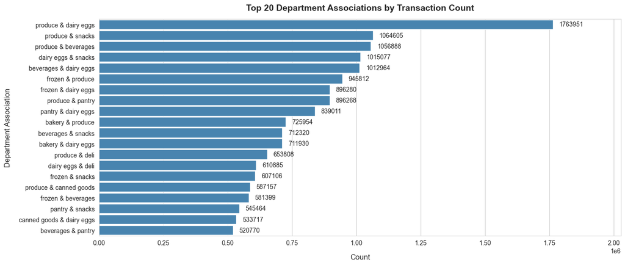

# Summary

This study applies market basket analysis to transactional retail data to identify purchasing associations at product and department levels and to develop association-based recommendation engines. Customer, product, and department purchasing behaviours were first characterized through engineered features, followed by the calculation of Support, Confidence, and Lift for product and department associations.

The analysis showed that frequently purchased product pairs are strongly influenced by product popularity, while Lift reveal additional relationships that occur substantially more often than expected from individual purchase frequencies. Customer-level associations further demonstrated the potential for personalized recommendations based on individual purchasing history.

Three recommendation approaches were developed: a product-level engine based on population-wide associations, a customer-level engine based on individual purchasing behaviour, and a combined engine integrating both sources of information. A text-based product similarity approach was also explored as a potential solution to the cold-start problem for newly introduced products.

Overall, the study demonstrates how transactional purchase data can be transformed into interpretable product associations and practical recommendation strategies, while highlighting considerations such as inventory availability, product price, and personalization for potential real-world implementation.

# About The Study

The objective of this study is to identify and quantify purchasing associations between products and departments using transactional retail data. Market basket analysis is applied to customer shopping baskets to reveal products and departments that tend to be purchased together.

The study evaluates these associations using Support, Confidence, and Lift, providing complementary measures of co-occurrence frequency, conditional purchasing behaviour, and the strength of relationships beyond what would be expected from individual purchase frequencies. These metrics are subsequently used as the basis for developing product-level, customer-level, and combined recommendation approaches.

# About The Dataset

The following study uses the Instacart Online Grocery dataset originaly provided by UCI Machine Learning Repository (now only available on Kaggle).

Dataset link: https://www.kaggle.com/datasets/yasserh/instacart-online-grocery-basket-analysis-dataset

```python
import gc
import pandas as pd
import numpy as np
import matplotlib.pyplot as plt
from itertools import combinations
from collections import Counter
import seaborn as sns
from sklearn.feature_extraction.text import TfidfVectorizer
from sklearn.metrics.pairwise import cosine_similarity

pd.set_option('display.max_rows', None)
pd.set_option('display.max_columns', None)
pd.set_option('display.max_colwidth', None)

def reduce_memory_usage(df):
    for col in df.columns:

        if pd.api.types.is_integer_dtype(df[col]):

            if df[col].min() >= 0:
                for dtype in [np.uint8, np.uint16, np.uint32, np.uint64]:
                    if df[col].max() <= np.iinfo(dtype).max:
                        df[col] = df[col].astype(dtype)
                        break
            else:
                for dtype in [np.int8, np.int16, np.int32, np.int64]:
                    info = np.iinfo(dtype)
                    if info.min <= df[col].min() and df[col].max() <= info.max:
                        df[col] = df[col].astype(dtype)
                        break

        elif pd.api.types.is_float_dtype(df[col]):
            df[col] = pd.to_numeric(df[col], downcast="float")

    return df
```

# Methodology

- Data Wrangling and Preprocessing
- Customer Analysis
- Product Analysis
- Department Analysis
- Market Basket Analysis
- Department Association Analysis
- Product-Level Recommendation Engine
- Customer-Level Recommendation Engine
- Combined Recommendation Engine
- Cold-Start Consideration for New Products
- Key Findings
- Conclusions

# Data Wrangling and Preprocessing

Five datasets, namely orders, order_products__prior, products, aisles, and departments, were loaded and merged into a single dataset for subsequent preprocessing and analysis. The order_products__train dataset was intentionally excluded, as the objective of this project is to explore purchasing behavior and product associations.

Each record in the resulting dataset represents a single product purchased within an order and contains information such as the order identifier, customer identifier, order sequence number, day of the week, hour of purchase, product identifier and name, aisle identifier and name, department identifier and name, add-to-cart position, reorder flag, and the number of days since the customer's previous order.

The eval_set feature was removed because it is not relevant to the objectives of this study. Furthermore, after merging the datasets into a single analytical table, the original dataframes were deleted to reduce memory usage, an important consideration given the size of the dataset.

Following the merge operation, the resulting dataset underwent a data type optimization procedure. Numerical features were automatically downcast to the smallest compatible integer or floating-point data types while preserving their original values. This optimization significantly reduced memory consumption by approximately 2 GB and improved the computational efficiency of subsequent processing steps.

```python
df_ord = pd.read_csv("orders.csv")
df_ord_prod = pd.read_csv("order_products__prior.csv")
df_prod = pd.read_csv("products.csv")
df_aisles = pd.read_csv("aisles.csv")
df_depart = pd.read_csv("departments.csv")
df_ord = df_ord[df_ord["eval_set"] == "prior"]
df_ord = df_ord.drop(columns="eval_set")
df_all = df_ord.merge(df_ord_prod, on="order_id", how="left")
df_all = df_all.merge(df_prod, on="product_id", how="left")
df_all = df_all.merge(df_aisles, on="aisle_id", how="left")
df_all = df_all.merge(df_depart, on="department_id", how="left")
del df_ord, df_ord_prod, df_prod, df_aisles, df_depart
gc.collect()
df_all = reduce_memory_usage(df_all)
df_all.info(verbose=False)
```

```
<class 'pandas.core.frame.DataFrame'>
RangeIndex: 32434489 entries, 0 to 32434488
Columns: 14 entries, order_id to department
dtypes: float32(1), object(3), uint16(1), uint32(2), uint8(7)
memory usage: 1.4+ GB
```

An initial inspection of the dataset revealed a substantial number of missing values in the days_since_prior_order feature. These missing values correspond to each customer's first recorded order, for which no previous purchase exists. Consequently, they were replaced with zero to indicate the absence of a prior ordering interval while preserving all observations for subsequent analyses.

```python
df_all.isna().sum().reset_index(name="Count").rename(columns={"index": "Feature"}).query("Count > 0").style.hide(axis="index")
```

| Feature | Count |
| --- | --- |
| days_since_prior_order | 2078068 |

```python
df_all["days_since_prior_order"] = df_all["days_since_prior_order"].fillna(0)
#df_all["is_first_order"] = (df_all["order_number"] == 1).astype(np.uint8)
```

The summary statistics of the resulting dataset are presented below.

```python
df_all.describe(include="all")
```

|  | order_id | user_id | order_number | order_dow | order_hour_of_day | days_since_prior_order | product_id | add_to_cart_order | reordered | product_name | aisle_id | department_id | aisle | department |
| --- | --- | --- | --- | --- | --- | --- | --- | --- | --- | --- | --- | --- | --- | --- |
| count | 3.243449e+07 | 3.243449e+07 | 3.243449e+07 | 3.243449e+07 | 3.243449e+07 | 3.243449e+07 | 3.243449e+07 | 3.243449e+07 | 3.243449e+07 | 32434489 | 3.243449e+07 | 3.243449e+07 | 32434489 | 32434489 |
| unique | NaN | NaN | NaN | NaN | NaN | NaN | NaN | NaN | NaN | 49677 | NaN | NaN | 134 | 21 |
| top | NaN | NaN | NaN | NaN | NaN | NaN | NaN | NaN | NaN | Banana | NaN | NaN | fresh fruits | produce |
| freq | NaN | NaN | NaN | NaN | NaN | NaN | NaN | NaN | NaN | 472565 | NaN | NaN | 3642188 | 9479291 |
| mean | 1.710749e+06 | 1.029372e+05 | 1.714205e+01 | 2.738818e+00 | 1.342498e+01 | 1.039264e+01 | 2.557634e+04 | 8.351076e+00 | 5.896975e-01 | NaN | 7.121430e+01 | 9.921906e+00 | NaN | NaN |
| std | 9.873007e+05 | 5.946648e+04 | 1.753504e+01 | 2.090049e+00 | 4.246365e+00 | 8.917691e+00 | 1.409669e+04 | 7.126671e+00 | 4.918886e-01 | NaN | 3.820302e+01 | 6.281156e+00 | NaN | NaN |
| min | 2.000000e+00 | 1.000000e+00 | 1.000000e+00 | 0.000000e+00 | 0.000000e+00 | 0.000000e+00 | 1.000000e+00 | 1.000000e+00 | 0.000000e+00 | NaN | 1.000000e+00 | 1.000000e+00 | NaN | NaN |
| 25% | 8.559430e+05 | 5.142100e+04 | 5.000000e+00 | 1.000000e+00 | 1.000000e+01 | 4.000000e+00 | 1.353000e+04 | 3.000000e+00 | 0.000000e+00 | NaN | 3.100000e+01 | 4.000000e+00 | NaN | NaN |
| 50% | 1.711048e+06 | 1.026110e+05 | 1.100000e+01 | 3.000000e+00 | 1.300000e+01 | 7.000000e+00 | 2.525600e+04 | 6.000000e+00 | 1.000000e+00 | NaN | 8.300000e+01 | 9.000000e+00 | NaN | NaN |
| 75% | 2.565514e+06 | 1.543910e+05 | 2.400000e+01 | 5.000000e+00 | 1.600000e+01 | 1.400000e+01 | 3.793500e+04 | 1.100000e+01 | 1.000000e+00 | NaN | 1.070000e+02 | 1.600000e+01 | NaN | NaN |
| max | 3.421083e+06 | 2.062090e+05 | 9.900000e+01 | 6.000000e+00 | 2.300000e+01 | 3.000000e+01 | 4.968800e+04 | 1.450000e+02 | 1.000000e+00 | NaN | 1.340000e+02 | 2.100000e+01 | NaN | NaN |

# Customer Analysis

The next stage focused on customer behavior analysis. To characterize purchasing habits, a set of customer-level features was engineered, including the total number of orders, preferred purchase hour and day of the week, customer loyalty (measured as the proportion of reordered products), average basket size, the number of distinct departments visited, product diversity, the share of purchases represented by the customer's most frequently purchased product, the average number of days between consecutive orders, and the customer's total lifetime measured in days. The summary statistics of the customer_behavior are presented below.

```python
customer_behavior = df_all.groupby("user_id").agg(
    TotalOrders=("order_number", "max"),
    PurchaseHour=("order_hour_of_day", lambda x: x.value_counts().idxmax()),
    PurchaseDOW=("order_dow", lambda x: x.value_counts().idxmax()),
    Loyalty=("reordered", "mean"),
    AvgBasketSize=("order_id", lambda x: x.size / x.nunique()),
    CountDepartmentsVisited=("department_id", "nunique"),
    ProductDiversity=("product_id", "nunique"),
    TopProductShare=("product_id", lambda x: x.value_counts().max() / x.size),
    AvgDaysBetweenOrders=("days_since_prior_order", "mean"),
    CustomerLifetime=("days_since_prior_order", "sum")
)
customer_behavior = reduce_memory_usage(customer_behavior)
customer_behavior.describe().round(2)
```

|  | TotalOrders | PurchaseHour | PurchaseDOW | Loyalty | AvgBasketSize | CountDepartmentsVisited | ProductDiversity | TopProductShare | AvgDaysBetweenOrders | CustomerLifetime |
| --- | --- | --- | --- | --- | --- | --- | --- | --- | --- | --- |
| count | 206209.00 | 206209.00 | 206209.00 | 206209.00 | 206209.00 | 206209.00 | 206209.00 | 206209.00 | 206209.00 | 206209.00 |
| mean | 15.59 | 13.42 | 2.58 | 0.43 | 9.95 | 10.83 | 64.54 | 0.10 | 13.01 | 1634.65 |
| std | 16.65 | 3.99 | 2.16 | 0.21 | 5.86 | 3.79 | 56.59 | 0.09 | 5.66 | 1618.93 |
| min | 3.00 | 0.00 | 0.00 | 0.00 | 1.00 | 1.00 | 1.00 | 0.01 | 0.00 | 0.00 |
| 25% | 5.00 | 10.00 | 1.00 | 0.27 | 5.74 | 8.00 | 25.00 | 0.05 | 8.48 | 492.00 |
| 50% | 9.00 | 13.00 | 2.00 | 0.43 | 8.93 | 11.00 | 48.00 | 0.07 | 12.67 | 1098.00 |
| 75% | 19.00 | 16.00 | 5.00 | 0.60 | 13.00 | 14.00 | 86.00 | 0.11 | 17.19 | 2251.00 |
| max | 99.00 | 23.00 | 6.00 | 0.99 | 70.25 | 21.00 | 726.00 | 1.00 | 29.70 | 21514.00 |

Customer purchasing behavior exhibits substantial variability. While some customers purchase only a limited range of products and place relatively few orders, others demonstrate high purchasing frequency, broad product diversity, and strong loyalty through repeated purchases. This heterogeneity motivates the use of personalized recommendation strategies rather than a one-size-fits-all approach. The histograms below show that the distribution of the average basket size is positively skewed, indicating that most customers purchase relatively few products per order, while a smaller proportion place considerably larger orders. In contrast, the average number of days between consecutive orders exhibits an approximately normal distribution, suggesting that the majority of customers follow relatively consistent purchasing intervals.

[figure not shown]

```python
def plot_avg_basket_size_and_avg_days_between_orders(data):
    sns.set_style("whitegrid")
    fig, axes = plt.subplots(1, 2, figsize=(14, 3.5))

    color = sns.color_palette("Blues", n_colors=5)[4]
    sns.histplot(
        data["AvgBasketSize"],
        bins=10,
        color=color,
        edgecolor="white",
        ax=axes[0]
    )
    axes[0].tick_params(axis='x', rotation=0)
    axes[0].set_title("Average Basket Size", fontsize=14, fontweight="bold", pad=14)
    axes[0].set_xlabel("Average Basket Size", fontsize=12)
    axes[0].set_ylabel("Customers", fontsize=12)

    sns.histplot(
        data["AvgDaysBetweenOrders"],
        bins=10,
        color=color,
        edgecolor="white",
        ax=axes[1]
    )
    axes[1].tick_params(axis='x', rotation=0)
    axes[1].set_title("Average Days Between Orders", fontsize=14, fontweight="bold", pad=14)
    axes[1].set_xlabel("Average Days Between Orders", fontsize=12)
    axes[1].set_ylabel("Customers", fontsize=12)
    plt.tight_layout()
    sns.despine()
    plt.show()
plot_avg_basket_size_and_avg_days_between_orders(customer_behavior)
```

# Product Analysis

Product behavior was characterized through a set of engineered product-level features, including purchase count, the number of unique customers, reorder rate, average cart position, and the preferred purchase hour and day of the week. Together, these features provide a quantitative description of product popularity, customer reach, and purchasing patterns. The summary statistics are presented below.

```python
product_behavior = df_all.groupby("product_id").agg(
    PurchaseCount=("order_id", "count"),
    UniqueCustomers=("user_id", "nunique"),
    ReorderRate=("reordered", "mean"),
    AvgCartPosition=("add_to_cart_order", "mean"),
    PreferredHour=("order_hour_of_day", lambda x: x.value_counts().idxmax()),
    PreferredDOW=("order_dow", lambda x: x.value_counts().idxmax())
)
product_behavior = reduce_memory_usage(product_behavior)
product_behavior.describe().round(2)
```

|  | PurchaseCount | UniqueCustomers | ReorderRate | AvgCartPosition | PreferredHour | PreferredDOW |
| --- | --- | --- | --- | --- | --- | --- |
| count | 49677.00 | 49677.00 | 49677.00 | 49677.00 | 49677.00 | 49677.00 |
| mean | 652.91 | 267.89 | 0.37 | 9.10 | 13.03 | 2.05 |
| std | 4792.11 | 1308.79 | 0.21 | 2.55 | 2.95 | 2.19 |
| min | 1.00 | 1.00 | 0.00 | 1.00 | 0.00 | 0.00 |
| 25% | 17.00 | 11.00 | 0.21 | 7.63 | 11.00 | 0.00 |
| 50% | 60.00 | 35.00 | 0.38 | 9.06 | 13.00 | 1.00 |
| 75% | 260.00 | 137.00 | 0.53 | 10.36 | 15.00 | 4.00 |
| max | 472565.00 | 73956.00 | 0.94 | 53.00 | 23.00 | 6.00 |

The summary statistics indicate that the average reorder rate is close to its median value, suggesting a relatively balanced distribution of product repurchases across the catalog. Furthermore, the average cart position is highly concentrated, with most products typically added to the shopping cart between the sixth and tenth positions. This indicates that, despite differences in popularity and purchasing frequency, products tend to occupy similar positions within customers' shopping baskets.

The preferred purchase hour shows that three quarters of the products are most frequently purchased before 15:00, while the preferred purchase day indicates that half of the products are most commonly purchased on Sunday or Monday. Together, these findings suggest the existence of consistent temporal purchasing patterns across a large proportion of the product catalog.

[figure not shown]

```python
def plot_avg_reorder_rate_and_avg_cart_position(data):
    sns.set_style("whitegrid")
    fig, axes = plt.subplots(1, 2, figsize=(14, 3.5))

    color=sns.color_palette("Blues", n_colors=5)[4]
    sns.histplot(
        data["ReorderRate"],
        bins=10,
        color=color,
        edgecolor="white",
        ax=axes[0]
    )
    axes[0].tick_params(axis='x', rotation=0)
    axes[0].set_title("Reorder Rate", fontsize=14, fontweight="bold", pad=14)
    axes[0].set_xlabel("Average Reorder Rate", fontsize=12)
    axes[0].set_ylabel("Products", fontsize=12)

    sns.histplot(
        data["AvgCartPosition"],
        bins=10,
        color=color,
        edgecolor="white",
        ax=axes[1]
    )
    axes[1].tick_params(axis='x', rotation=0)
    axes[1].set_title("Average Cart Position", fontsize=14, fontweight="bold", pad=14)
    axes[1].set_xlabel("Average Cart Position", fontsize=12)
    axes[1].set_ylabel("Products", fontsize=12)
    plt.tight_layout()
    sns.despine()
    plt.show()
plot_avg_reorder_rate_and_avg_cart_position(product_behavior)
```

# Department Analysis

To characterize department behavior, a set of department-level features was engineered, including the number of products, purchase count, the number of unique customers, reorder rate, average cart position, and the preferred purchase hour and day of the week. These features describe the relative size of each department, its customer reach, and the purchasing behavior associated with its products. The summary statistics are presented below.

```python
department_behavior = df_all.groupby("department_id").agg(
    NumberOfProducts=("product_id", "nunique"),
    PurchaseCount=("order_id", "count"),
    UniqueCustomers=("user_id", "nunique"),
    ReorderRate=("reordered", "mean"),
    AvgCartPosition=("add_to_cart_order", "mean"),
    PreferredHour=("order_hour_of_day", lambda x: x.value_counts().idxmax()),
    PreferredDOW=("order_dow", lambda x: x.value_counts().idxmax())
)
department_behavior = reduce_memory_usage(department_behavior)
department_behavior.describe().round(2)
```

|  | NumberOfProducts | PurchaseCount | UniqueCustomers | ReorderRate | AvgCartPosition | PreferredHour | PreferredDOW |
| --- | --- | --- | --- | --- | --- | --- | --- |
| count | 21.00 | 21.00 | 21.00 | 21.00 | 21.00 | 21.00 | 21.00 |
| mean | 2365.57 | 1544499.48 | 106323.29 | 0.52 | 8.66 | 11.71 | 0.43 |
| std | 1914.14 | 2231519.25 | 63298.74 | 0.11 | 1.18 | 2.35 | 1.12 |
| min | 38.00 | 34573.00 | 12484.00 | 0.32 | 5.43 | 9.00 | 0.00 |
| 25% | 1081.00 | 269253.00 | 33730.00 | 0.41 | 8.08 | 10.00 | 0.00 |
| 50% | 1516.00 | 738666.00 | 114169.00 | 0.57 | 8.69 | 10.00 | 0.00 |
| 75% | 3448.00 | 1875577.00 | 163233.00 | 0.60 | 9.34 | 14.00 | 0.00 |
| max | 6563.00 | 9479291.00 | 193237.00 | 0.67 | 10.58 | 16.00 | 5.00 |

The summary statistics indicate that, in contrast to the product level, the reorder rate varies within a relatively narrow range across departments. Approximately half of the departments exhibit a reorder rate greater than 0.5, indicating that more than half of the products purchased within these departments are repeat purchases. In contrast, purchase count exhibits a markedly skewed distribution, with more than half of the departments accounting for a relatively small number of purchases, while only a few departments dominate the total purchase volume.

[figure not shown]

```python
def plot_avg_reorder_rate_and_purchase_count(data):
    sns.set_style("whitegrid")
    fig, axes = plt.subplots(1, 2, figsize=(14, 3.5))

    color=sns.color_palette("Blues", n_colors=5)[4]
    sns.histplot(
        data["ReorderRate"],
        bins=10,
        color=color,
        edgecolor="white",
        ax=axes[0]
    )
    axes[0].tick_params(axis='x', rotation=0)
    axes[0].set_title("Reorder Rate", fontsize=14, fontweight="bold", pad=14)
    axes[0].set_xlabel("Average Reorder Rate", fontsize=12)
    axes[0].set_ylabel("Departments", fontsize=12)

    sns.histplot(
        data["PurchaseCount"],
        bins=10,
        color=color,
        edgecolor="white",
        ax=axes[1]
    )
    axes[1].tick_params(axis='x', rotation=0)
    axes[1].set_title("Purchase Count", fontsize=14, fontweight="bold", pad=14)
    axes[1].set_xlabel("Purchase Count", fontsize=12)
    axes[1].set_ylabel("Departments", fontsize=12)
    plt.tight_layout()
    sns.despine()
    plt.show()
plot_avg_reorder_rate_and_purchase_count(department_behavior)
```

# Market Basket Analysis

Market Basket Analysis aims to identify products that are frequently purchased together by analyzing customer shopping baskets. In this study, each order was treated as an individual basket, from which all unique product pairs were generated. Product associations were subsequently quantified using three widely adopted metrics, namely Support, Confidence, and Lift, which together provide complementary measures of co-occurrence frequency, recommendation strength, and statistical dependence between products. The following table presents an example of the shopping baskets generated from the transaction data for the subsequent Market Basket Analysis. Each basket corresponds to a unique order and contains the list of product identifiers purchased within that transaction.

```python
def generate_pairs(feature="product_id"):
    column_names = {"Products" : ["ProductA", "ProductB"], "Departments" : ["DepartmentA", "DepartmentB"]}
    popular_products = product_behavior.loc[product_behavior["PurchaseCount"] >= 100].index

    baskets = df_all[df_all["product_id"].isin(popular_products)].groupby("order_id")[feature].apply(list)
    baskets = baskets.apply(lambda x: sorted(set(x)))
    baskets = baskets[baskets.str.len() >= 2]
    baskets = baskets.rename(feature + "_basket")

    pair_counter = Counter()

    for basket in baskets:
        pair_counter.update(combinations(basket, 2))

    pair_df = pd.DataFrame(
        pair_counter.items(),
        columns=["Pair", "Count"]
    )

    output_features = column_names["Products"] if feature == "product_id" else column_names["Departments"]

    pair_df[output_features] = pd.DataFrame(
        pair_df["Pair"].tolist(),
        index=pair_df.index
    )
    return pair_df.drop(columns="Pair"), baskets
pair_df, baskets = generate_pairs("product_id")
baskets.tail().reset_index().style.hide(axis="index")
```

| order_id | product_id_basket |
| --- | --- |
| 3421078 | [14553, 22760, 24852, 33750, 37646, 38656, 40396, 41844, 48577] |
| 3421080 | [4932, 10667, 12935, 18811, 25122, 27845, 31717, 38061, 41950] |
| 3421081 | [3060, 12218, 32299, 35221, 38185] |
| 3421082 | [12023, 12738, 16797, 17279, 32700, 43352, 47941] |
| 3421083 | [4600, 5020, 7854, 11352, 18176, 21162, 24852, 35211, 39678, 45309] |

To quantify the strength of the associations between products, a set of additional features was created for each product pair. CountA and CountB represent the individual purchase counts of Products A and B, respectively. Support measures the proportion of orders in which both products were purchased together, while SupportA and SupportB represent the proportion of orders containing Products A and B individually. Confidence_AtoB quantifies the conditional probability of purchasing Product B given that Product A was purchased, whereas Confidence_BtoA measures the reverse relationship. Lift evaluates the strength of the association between two products relative to what would be expected if they were purchased independently, with values greater than one indicating a stronger-than-expected relationship. Additional descriptive features, including ProductA_Name, ProductB_Name, DepartmentA, and DepartmentB, were also created to facilitate the interpretation of the identified associations.

```python
pair_df["CountA"] = pair_df["ProductA"].map(product_behavior["PurchaseCount"])
pair_df["CountB"] = pair_df["ProductB"].map(product_behavior["PurchaseCount"])
number_of_orders = len(baskets)
pair_df["Support"] = pair_df["Count"] / number_of_orders
pair_df["SupportA"] = pair_df["CountA"] / number_of_orders
pair_df["SupportB"] = pair_df["CountB"] / number_of_orders
pair_df["Confidence_AtoB"] = pair_df["Count"] / pair_df["CountA"]
pair_df["Confidence_BtoA"] = pair_df["Count"] / pair_df["CountB"]
pair_df["Lift"] = pair_df["Count"] * number_of_orders / ( pair_df["CountA"] * pair_df["CountB"] )
product_id_name = df_all.groupby("product_id")["product_name"].first()
pair_df["ProductA_Name"] = pair_df["ProductA"].map(product_id_name)
pair_df["ProductB_Name"] = pair_df["ProductB"].map(product_id_name)
department_id_name = df_all.groupby("product_id")["department"].first()
pair_df["DepartmentA"] = pair_df["ProductA"].map(department_id_name)
pair_df["DepartmentB"] = pair_df["ProductB"].map(department_id_name)
pair_df = reduce_memory_usage(pair_df)
del product_id_name, department_id_name
gc.collect()
```

```
0
```

### Most Frequent Purchased Product Pairs

The following table presents the 20 most frequently purchased product pairs, ranked according to their co-occurrence count. ProductA and ProductB correspond to the product identifiers. The results show that the products composing the most frequently purchased pairs predominantly belong to the same department. In most cases, the paired products consist of complementary or otherwise distinct products rather than different variations of the same underlying product. Fresh produce, particularly bananas and organic fruits and vegetables, dominates the ranking, indicating that this category accounts for the highest purchase frequency in the dataset. The predominance of food-related pairs may also be explained by the fact that food products account for approximately 96% of all product purchases.

Although co-occurrence count effectively identifies the most common product combinations, it is strongly influenced by product popularity. Consequently, additional association metrics, such as Confidence and Lift, are required to distinguish genuinely strong product relationships from those driven primarily by high individual purchase frequencies.

```python
pairs_most_frequently_purchased = pair_df.nlargest(20, "Count")
pairs_most_frequently_purchased.style.hide(axis="index").set_properties(**{"white-space": "nowrap"})
```

| Count | ProductA | ProductB | CountA | CountB | Support | SupportA | SupportB | Confidence_AtoB | Confidence_BtoA | Lift | ProductA_Name | ProductB_Name | DepartmentA | DepartmentB |
| --- | --- | --- | --- | --- | --- | --- | --- | --- | --- | --- | --- | --- | --- | --- |
| 62341 | 13176 | 47209 | 379450 | 213584 | 0.020484 | 0.124678 | 0.070178 | 0.164293 | 0.291880 | 50.797810 | Bag of Organic Bananas | Organic Hass Avocado | produce | produce |
| 61628 | 13176 | 21137 | 379450 | 264683 | 0.020249 | 0.124678 | 0.086968 | 0.162414 | 0.232837 | 113.693314 | Bag of Organic Bananas | Organic Strawberries | produce | produce |
| 56156 | 21137 | 24852 | 264683 | 472565 | 0.018451 | 0.086968 | 0.155273 | 0.212163 | 0.118832 | 325.000244 | Organic Strawberries | Banana | produce | produce |
| 53395 | 24852 | 47766 | 472565 | 176815 | 0.017544 | 0.155273 | 0.058097 | 0.112990 | 0.301982 | 83.241913 | Banana | Organic Avocado | produce | produce |
| 51395 | 21903 | 24852 | 241921 | 472565 | 0.016887 | 0.079489 | 0.155273 | 0.212445 | 0.108758 | 58.931244 | Organic Baby Spinach | Banana | produce | produce |
| 50372 | 13176 | 21903 | 379450 | 241921 | 0.016551 | 0.124678 | 0.079489 | 0.132750 | 0.208217 | 95.659355 | Bag of Organic Bananas | Organic Baby Spinach | produce | produce |
| 41232 | 16797 | 24852 | 142951 | 472565 | 0.013548 | 0.046970 | 0.155273 | 0.288435 | 0.087251 | 40.103012 | Strawberries | Banana | produce | produce |
| 40880 | 24852 | 47626 | 472565 | 152657 | 0.013432 | 0.155273 | 0.050159 | 0.086507 | 0.267790 | 36.369675 | Banana | Large Lemon | produce | produce |
| 40794 | 21137 | 47209 | 264683 | 213584 | 0.013404 | 0.086968 | 0.070178 | 0.154124 | 0.190997 | 178.004639 | Organic Strawberries | Organic Hass Avocado | produce | produce |
| 40503 | 13176 | 27966 | 379450 | 137057 | 0.013308 | 0.124678 | 0.045033 | 0.106741 | 0.295519 | 264.145050 | Bag of Organic Bananas | Organic Raspberries | produce | produce |
| 38134 | 21137 | 21903 | 264683 | 241921 | 0.012530 | 0.086968 | 0.079489 | 0.144074 | 0.157630 | 29.737089 | Organic Strawberries | Organic Baby Spinach | produce | produce |
| 34901 | 21903 | 47209 | 241921 | 213584 | 0.011468 | 0.079489 | 0.070178 | 0.144266 | 0.163406 | 811.781677 | Organic Baby Spinach | Organic Hass Avocado | produce | produce |
| 33943 | 24852 | 28204 | 472565 | 89632 | 0.011153 | 0.155273 | 0.029451 | 0.071827 | 0.378693 | 27.903057 | Banana | Organic Fuji Apple | produce | produce |
| 33863 | 21137 | 27966 | 264683 | 137057 | 0.011127 | 0.086968 | 0.045033 | 0.127938 | 0.247072 | 53.763523 | Organic Strawberries | Organic Raspberries | produce | produce |
| 32097 | 24852 | 49683 | 472565 | 97315 | 0.010546 | 0.155273 | 0.031975 | 0.067921 | 0.329826 | 32.154686 | Banana | Cucumber Kirby | produce | produce |
| 31772 | 24852 | 26209 | 472565 | 140627 | 0.010439 | 0.155273 | 0.046206 | 0.067233 | 0.225931 | 47.612892 | Banana | Limes | produce | produce |
| 31641 | 24852 | 27845 | 472565 | 137905 | 0.010396 | 0.155273 | 0.045312 | 0.066956 | 0.229441 | 129.333984 | Banana | Organic Whole Milk | produce | dairy eggs |
| 31222 | 24852 | 47209 | 472565 | 213584 | 0.010259 | 0.155273 | 0.070178 | 0.066069 | 0.146181 | 44.236160 | Banana | Organic Hass Avocado | produce | produce |
| 30889 | 21903 | 47766 | 241921 | 176815 | 0.010149 | 0.079489 | 0.058097 | 0.127682 | 0.174697 | 22.814671 | Organic Baby Spinach | Organic Avocado | produce | produce |
| 28408 | 24852 | 45066 | 472565 | 79769 | 0.009334 | 0.155273 | 0.026210 | 0.060114 | 0.356128 | 25.914442 | Banana | Honeycrisp Apple | produce | produce |

### Strongest Recommendation Relationships

The following table presents the 20 strongest recommendation relationships, ranked according to the maximum confidence observed between the two products in each pair. For this analysis, only pairs of products purchased together at least 20 times were considered. ProductA and ProductB correspond to the product identifiers.

Among the top 100 recommendation relationships, 83% involve products belonging to the same department, but pairs span different departments. In contrast to the most frequently purchased pairs, many of these relationships involve products that may be considered variations or substitutes rather than complementary products. Examples include "Simply 100 Crunch Blueberry Cookie Crumble Non-Fat Greek Yogurt" and "Simply 100 Crunch Mango Cone Crisp Non-Fat Greek Yogurt", as well as "Grain Free Chicken Formula Cat Food" and "Grain Free Turkey Canned Cat Food".

Other pairs consist of completely distinct products, indicating that strong recommendation relationships are not limited to product variations or substitutes. Although food departments predominate, many of the products cannot necessarily be considered essential food items. Most of the selected pairs exhibit high Confidence_AtoB, Confidence_BtoA, and Lift values, indicating that the products tend to be purchased together substantially more often than would be expected from their individual purchase frequencies.

The results also show that strong recommendation relationships are not necessarily associated with the most frequently purchased products, as several pairs have substantially lower co-occurrence counts than those observed among the most frequently purchased pairs.

```python
strongest_recommendations = pd.concat( [pair_df[pair_df["Count"] >= 20].nlargest(100, "Confidence_AtoB"), pair_df[pair_df["Count"] >= 20].nlargest(100, "Confidence_BtoA")], ignore_index=True ).assign( Confidence=lambda x: x[["Confidence_AtoB", "Confidence_BtoA"]].max(axis=1) ).nlargest(100, "Confidence")
strongest_recommendations.nlargest(20, "Confidence").style.hide(axis="index").set_properties(**{"white-space": "nowrap"})
```

| Count | ProductA | ProductB | CountA | CountB | Support | SupportA | SupportB | Confidence_AtoB | Confidence_BtoA | Lift | ProductA_Name | ProductB_Name | DepartmentA | DepartmentB | Confidence |
| --- | --- | --- | --- | --- | --- | --- | --- | --- | --- | --- | --- | --- | --- | --- | --- |
| 202 | 3858 | 15692 | 511 | 260 | 0.000066 | 0.000168 | 0.000085 | 0.395303 | 0.776923 | 4627.253418 | 2nd Foods Chicken & Gravy | 2nd Foods Turkey Meat | babies | babies | 0.776923 |
| 76 | 27740 | 47231 | 101 | 1489 | 0.000025 | 0.000033 | 0.000489 | 0.752475 | 0.051041 | 1538.026001 | Chocolate Love Bar | Ultra-Purified Water | snacks | beverages | 0.752475 |
| 75 | 27740 | 47512 | 101 | 401 | 0.000025 | 0.000033 | 0.000132 | 0.742574 | 0.187032 | 5635.879395 | Chocolate Love Bar | Lite Energy Drink | snacks | beverages | 0.742574 |
| 71 | 20817 | 33425 | 212 | 103 | 0.000023 | 0.000070 | 0.000034 | 0.334906 | 0.689320 | 9895.811523 | Chicken Sticks | Graduates Turkey Sticks | babies | babies | 0.689320 |
| 188 | 18229 | 21653 | 283 | 1543 | 0.000062 | 0.000093 | 0.000507 | 0.664311 | 0.121841 | 1310.302734 | Plastic Knives | Compostable Forks | household | household | 0.664311 |
| 1502 | 13269 | 44786 | 2857 | 2272 | 0.000494 | 0.000939 | 0.000747 | 0.525726 | 0.661092 | 704.234863 | Oh My Yog! Pacific Coast Strawberry Trilayer Yogurt | Oh My Yog! Organic Wild Quebec Blueberry Cream Top Yogurt & Fruit | dairy eggs | snacks | 0.661092 |
| 1502 | 13269 | 44786 | 2857 | 2272 | 0.000494 | 0.000939 | 0.000747 | 0.525726 | 0.661092 | 704.234863 | Oh My Yog! Pacific Coast Strawberry Trilayer Yogurt | Oh My Yog! Organic Wild Quebec Blueberry Cream Top Yogurt & Fruit | dairy eggs | snacks | 0.661092 |
| 324 | 7076 | 28134 | 1825 | 504 | 0.000106 | 0.000600 | 0.000166 | 0.177534 | 0.642857 | 1072.056763 | Grain Free Chicken Formula Cat Food | Grain Free Turkey Canned Cat Food | pets | pets | 0.642857 |
| 216 | 15697 | 26810 | 337 | 584 | 0.000071 | 0.000111 | 0.000192 | 0.640950 | 0.369863 | 3340.236084 | Apricot Walnut & Coconut Granola Bar | Organic Date Pecan & Coconut Granola Bar | snacks | snacks | 0.640950 |
| 64 | 17540 | 19660 | 100 | 56087 | 0.000021 | 0.000033 | 0.018429 | 0.640000 | 0.001141 | 34.728333 | Burnt Sugar Vanilla Ice Cream | Spring Water | frozen | beverages | 0.640000 |
| 67 | 29541 | 30551 | 105 | 450 | 0.000022 | 0.000035 | 0.000148 | 0.638095 | 0.148889 | 4315.580078 | Farmstyle Greek Strained Yogurt Oregon Blueberry, 2% Milkfat | Farmstyle Greek Old Fashioned Vanilla Strained Lowfat Yogurt | dairy eggs | dairy eggs | 0.638095 |
| 75 | 12995 | 18531 | 120 | 24664 | 0.000025 | 0.000039 | 0.008104 | 0.625000 | 0.003041 | 77.122780 | Cacao Hemp Walnut Bar | Organic Heavy Whipping Cream | snacks | dairy eggs | 0.625000 |
| 74 | 11572 | 33258 | 119 | 190 | 0.000024 | 0.000039 | 0.000062 | 0.621849 | 0.389474 | 9960.871094 | Superfood Currant Cacao & Hemp Seedbar | Superfood Organic Gluten Free Mulberry Cacao Seedbar | snacks | snacks | 0.621849 |
| 69 | 38251 | 49544 | 111 | 1835 | 0.000023 | 0.000036 | 0.000603 | 0.621622 | 0.037602 | 1030.994141 | Benchbreak Chardonnay | Cabernet Sauvignon Wine | alcohol | alcohol | 0.621622 |
| 128 | 9055 | 17573 | 336 | 206 | 0.000042 | 0.000110 | 0.000068 | 0.380952 | 0.621359 | 5628.201660 | Farmstyle Greek Strained Yogurt Oregon Strawberry, 2% Milkfat | Farmstyle Greek Strained Yogurt Washington Raspberry, 2% Milkfat | dairy eggs | dairy eggs | 0.621359 |
| 108 | 6508 | 29416 | 2569 | 174 | 0.000035 | 0.000844 | 0.000057 | 0.042040 | 0.620690 | 735.320312 | Oh My Yog! Madagascar Vanilla Trilayer Yogyurt | Oh My Yog! Organic Maple | dairy eggs | dairy eggs | 0.620690 |
| 74 | 12995 | 19660 | 120 | 56087 | 0.000024 | 0.000039 | 0.018429 | 0.616667 | 0.001319 | 33.462196 | Cacao Hemp Walnut Bar | Spring Water | snacks | beverages | 0.616667 |
| 517 | 29126 | 36361 | 1168 | 839 | 0.000170 | 0.000384 | 0.000276 | 0.442637 | 0.616210 | 1605.653809 | Organic Strawberry Chia Lowfat 2% Cottage Cheese | Organic Cottage Cheese Blueberry Acai Chia | dairy eggs | dairy eggs | 0.616210 |
| 382 | 11224 | 39739 | 620 | 914 | 0.000126 | 0.000204 | 0.000300 | 0.616129 | 0.417943 | 2051.594971 | Organic Cashew Nondairy Blueberry Yogurt | Organic Nondairy Strawberry Cashew Yogurt | missing | missing | 0.616129 |
| 309 | 10863 | 28134 | 1560 | 504 | 0.000102 | 0.000513 | 0.000166 | 0.198077 | 0.613095 | 1196.105591 | Grain Free Turkey & Salmon Formula Cat Food | Grain Free Turkey Canned Cat Food | pets | pets | 0.613095 |

### Stronger Than Expected Relationships

The following table presents the 20 strongest-than-expected product relationships, ranked according to the maximum Lift observed between the two products in each pair. For this analysis, only pairs of products purchased together at least 500 times were considered. This relatively high co-occurrence threshold was applied to avoid identifying relationships based on very rare product combinations, which can produce disproportionately high Lift values. ProductA and ProductB correspond to the product identifiers.

Among the top 100 relationships, 78% involve products belonging to the same department, although pairs also span different departments. The identified relationships are diverse and include products that may be considered variations, substitutes, complementary products, or completely distinct products.

The Produce department, and food-related departments in general, dominate the top 20 relationships under this filtering criterion, with only a few pairs involving non-food departments. The high Lift values indicate that, despite the relatively high co-occurrence threshold, these products are purchased together substantially more often than would be expected based on their individual purchase frequencies.

As a final note, the identified product relationships remain unusually strong even when the analysis is restricted to combinations that occur frequently.

```python
stronger_than_expected_relationship = pair_df[pair_df["Count"] >= 500].nlargest(20, "Lift")
stronger_than_expected_relationship.style.hide(axis="index").set_properties(**{"white-space": "nowrap"})
```

| Count | ProductA | ProductB | CountA | CountB | Support | SupportA | SupportB | Confidence_AtoB | Confidence_BtoA | Lift | ProductA_Name | ProductB_Name | DepartmentA | DepartmentB |
| --- | --- | --- | --- | --- | --- | --- | --- | --- | --- | --- | --- | --- | --- | --- |
| 8199 | 4799 | 24852 | 36365 | 472565 | 0.002694 | 0.011949 | 0.155273 | 0.225464 | 0.017350 | 5033.899414 | Shredded Parmesan | Banana | dairy eggs | produce |
| 1500 | 33198 | 39275 | 42934 | 100060 | 0.000493 | 0.014107 | 0.032877 | 0.034937 | 0.014991 | 4525.603027 | Sparkling Natural Mineral Water | Organic Blueberries | beverages | produce |
| 3925 | 2966 | 24852 | 18183 | 472565 | 0.001290 | 0.005974 | 0.155273 | 0.215861 | 0.008306 | 4400.150391 | Pure Coconut Water | Banana | beverages | produce |
| 15421 | 17794 | 24852 | 72736 | 472565 | 0.005067 | 0.023899 | 0.155273 | 0.212013 | 0.032633 | 3681.175293 | Carrots | Banana | produce | produce |
| 1315 | 16797 | 42768 | 142951 | 30055 | 0.000432 | 0.046970 | 0.009875 | 0.009199 | 0.043753 | 2808.499268 | Strawberries | Organic Garbanzo Beans | produce | canned goods |
| 15570 | 47766 | 49683 | 176815 | 97315 | 0.005116 | 0.058097 | 0.031975 | 0.088058 | 0.159996 | 1762.724609 | Organic Avocado | Cucumber Kirby | produce | produce |
| 2288 | 12872 | 24852 | 9097 | 472565 | 0.000752 | 0.002989 | 0.155273 | 0.251511 | 0.004842 | 1759.989380 | Penne Rigate | Banana | dry goods pasta | produce |
| 3552 | 27845 | 42828 | 137905 | 31192 | 0.001167 | 0.045312 | 0.010249 | 0.025757 | 0.113875 | 1646.545410 | Organic Whole Milk | Whipped Cream Cheese | dairy eggs | dairy eggs |
| 517 | 29126 | 36361 | 1168 | 839 | 0.000170 | 0.000384 | 0.000276 | 0.442637 | 0.616210 | 1605.653809 | Organic Strawberry Chia Lowfat 2% Cottage Cheese | Organic Cottage Cheese Blueberry Acai Chia | dairy eggs | dairy eggs |
| 18982 | 24852 | 39275 | 472565 | 100060 | 0.006237 | 0.155273 | 0.032877 | 0.040168 | 0.189706 | 1436.596191 | Banana | Organic Blueberries | produce | produce |
| 2307 | 17872 | 21137 | 16246 | 264683 | 0.000758 | 0.005338 | 0.086968 | 0.142004 | 0.008716 | 1384.116699 | Total 2% Lowfat Plain Greek Yogurt | Organic Strawberries | dairy eggs | produce |
| 2897 | 44422 | 47209 | 20140 | 213584 | 0.000952 | 0.006617 | 0.070178 | 0.143843 | 0.013564 | 1332.968872 | Organic Old Fashioned Rolled Oats | Organic Hass Avocado | breakfast | produce |
| 508 | 16508 | 29479 | 1226 | 1003 | 0.000167 | 0.000403 | 0.000330 | 0.414356 | 0.506481 | 1257.298706 | Stage 3 Hearty Meals - Chick Chick Organic Baby Food | Gobble Gobble Turkey Pouch Stage 3 | babies | babies |
| 4597 | 8518 | 41950 | 66986 | 64289 | 0.001510 | 0.022010 | 0.021124 | 0.068626 | 0.071505 | 1217.045532 | Organic Red Onion | Organic Tomato Cluster | produce | produce |
| 2543 | 5450 | 5876 | 49021 | 87746 | 0.000836 | 0.016107 | 0.028831 | 0.051876 | 0.028981 | 1203.771606 | Small Hass Avocado | Organic Lemon | produce | produce |
| 3369 | 18027 | 21903 | 17789 | 241921 | 0.001107 | 0.005845 | 0.079489 | 0.189387 | 0.013926 | 1197.073730 | Ezekiel 4:9 Bread Organic Sprouted Whole Grain | Organic Baby Spinach | bakery | produce |
| 515 | 11983 | 34519 | 1270 | 1032 | 0.000169 | 0.000417 | 0.000339 | 0.405512 | 0.499031 | 1195.886597 | Simply 100 Strawberry Blended Non-Fat Greek Yogurt | Simply 100® Blueberry Blended Non-Fat Greek Yogurt | dairy eggs | dairy eggs |
| 5174 | 24489 | 27966 | 31445 | 137057 | 0.001700 | 0.010332 | 0.045033 | 0.164541 | 0.037751 | 1064.688110 | Organic Whole Strawberries | Organic Raspberries | frozen | produce |
| 2360 | 15290 | 24964 | 39188 | 109778 | 0.000775 | 0.012876 | 0.036070 | 0.060223 | 0.021498 | 1024.180054 | Orange Bell Pepper | Organic Garlic | produce | produce |
| 627 | 11212 | 12820 | 1249 | 1518 | 0.000206 | 0.000410 | 0.000499 | 0.502002 | 0.413043 | 1006.466919 | Apple Blueberry Fruit Yogurt Smoothie | Organic Fruit Yogurt Smoothie Mixed Berry | babies | babies |

# Department Association Analysis

Department Association Analysis aims to identify pairs of departments whose products are frequently purchased together by analyzing customer shopping baskets. As in the Market Basket Analysis, each order was treated as an individual basket, from which the unique departments represented in each order were identified and paired. Department associations were subsequently quantified using three widely adopted metrics, namely Support, Confidence, and Lift, which provide complementary measures of co-occurrence frequency, recommendation strength, and statistical dependence between departments.

The following table presents an example of the department baskets generated from the transaction data for the subsequent analysis. Each basket corresponds to a unique order and contains the list of department identifiers represented among the products purchased in that transaction. The dataset contains 21 different departments, with identifiers ranging from 1 to 21.

```python
depart_pair_df, department_level_baskets = generate_pairs("department_id")
department_level_baskets.tail().reset_index().style.hide(axis="index")
```

| order_id | department_id_basket |
| --- | --- |
| 3421078 | [4, 14, 16, 19, 20] |
| 3421080 | [1, 4, 7, 16] |
| 3421081 | [3, 7, 13, 16, 19] |
| 3421082 | [4, 12, 14, 16, 19] |
| 3421083 | [1, 4, 17, 18, 19] |

To quantify the strength of the associations between departments, a set of additional features was also created for each department pair. CountA and CountB represent the number of orders containing products from Departments A and B, respectively. Support measures the proportion of orders in which products from both departments were purchased together, while SupportA and SupportB represent the proportion of orders containing products from Departments A and B individually. Confidence_AtoB quantifies the conditional probability of purchasing a product from Department B given that a product from Department A was purchased, whereas Confidence_BtoA measures the reverse relationship. Lift evaluates the strength of the association between two departments relative to what would be expected if products from the departments were purchased independently, with values greater than one indicating a stronger-than-expected relationship.

```python
department_count = department_level_baskets.explode().value_counts()
depart_pair_df["CountA"] = depart_pair_df["DepartmentA"].map(department_count)
depart_pair_df["CountB"] = depart_pair_df["DepartmentB"].map(department_count)
number_of_orders = len(department_level_baskets)
depart_pair_df["Support"] = depart_pair_df["Count"] / number_of_orders
depart_pair_df["SupportA"] = depart_pair_df["CountA"] / number_of_orders
depart_pair_df["SupportB"] = depart_pair_df["CountB"] / number_of_orders
depart_pair_df["Confidence_AtoB"] = depart_pair_df["Count"] / depart_pair_df["CountA"]
depart_pair_df["Confidence_BtoA"] = depart_pair_df["Count"] / depart_pair_df["CountB"]
depart_pair_df["Lift"] = depart_pair_df["Count"] * number_of_orders / ( depart_pair_df["CountA"] * depart_pair_df["CountB"] )
department_id_name = df_all.groupby("department_id")["department"].first()
depart_pair_df["DepartmentA"] = depart_pair_df["DepartmentA"].map(department_id_name)
depart_pair_df["DepartmentB"] = depart_pair_df["DepartmentB"].map(department_id_name)
depart_pair_df = reduce_memory_usage(depart_pair_df)
del department_count, department_id_name
gc.collect()
```

The following table presents the top 20 department pairs, ranked according to the number of orders in which products from both departments were purchased together. Among the top 20 relationships, the Produce and Dairy & Eggs departments dominate, each appearing eight times in association with other departments. This suggests that these departments have particularly broad associations with other departments across customers' shopping baskets. Fresh food departments are also predominant, while Snacks is the only non-essential food department represented among the top 20 relationships. Of the 21 departments represented in the dataset, only nine appear among these 20 most frequent department relationships. The identified relationships are diverse and include combinations both within and across different types of food departments.

```python
depart_pair_df.nlargest(20, "Count").style.hide(axis="index")
```

| Count | DepartmentA | DepartmentB | CountA | CountB | Support | SupportA | SupportB | Confidence_AtoB | Confidence_BtoA | Lift |
| --- | --- | --- | --- | --- | --- | --- | --- | --- | --- | --- |
| 1763951 | produce | dairy eggs | 2310298 | 2127309 | 0.606394 | 0.794211 | 0.731305 | 0.763517 | 0.829194 | 1.044047 |
| 1064605 | produce | snacks | 2310298 | 1338348 | 0.365979 | 0.794211 | 0.460084 | 0.460809 | 0.795462 | 1.001575 |
| 1056888 | produce | beverages | 2310298 | 1379261 | 0.363326 | 0.794211 | 0.474149 | 0.457468 | 0.766271 | 0.964820 |
| 1015077 | dairy eggs | snacks | 2127309 | 1338348 | 0.348953 | 0.731305 | 0.460084 | 0.477165 | 0.758455 | 1.037125 |
| 1012964 | beverages | dairy eggs | 1379261 | 2127309 | 0.348227 | 0.474149 | 0.731305 | 0.734425 | 0.476172 | 1.004266 |
| 945812 | frozen | produce | 1149792 | 2310298 | 0.325142 | 0.395264 | 0.794211 | 0.822594 | 0.409390 | 1.035737 |
| 896280 | frozen | dairy eggs | 1149792 | 2127309 | 0.308114 | 0.395264 | 0.731305 | 0.779515 | 0.421321 | 1.065923 |
| 896268 | produce | pantry | 2310298 | 1073946 | 0.308110 | 0.794211 | 0.369191 | 0.387945 | 0.834556 | 1.050798 |
| 839011 | pantry | dairy eggs | 1073946 | 2127309 | 0.288427 | 0.369191 | 0.731305 | 0.781241 | 0.394400 | 1.068284 |
| 725954 | bakery | produce | 862329 | 2310298 | 0.249561 | 0.296443 | 0.794211 | 0.841853 | 0.314225 | 1.059986 |
| 712320 | beverages | snacks | 1379261 | 1338348 | 0.244874 | 0.474149 | 0.460084 | 0.516450 | 0.532238 | 1.122513 |
| 711930 | bakery | dairy eggs | 862329 | 2127309 | 0.244740 | 0.296443 | 0.731305 | 0.825590 | 0.334662 | 1.128927 |
| 653808 | produce | deli | 2310298 | 754474 | 0.224760 | 0.794211 | 0.259366 | 0.282997 | 0.866575 | 1.091113 |
| 610885 | dairy eggs | deli | 2127309 | 754474 | 0.210004 | 0.731305 | 0.259366 | 0.287163 | 0.809683 | 1.107176 |
| 607106 | frozen | snacks | 1149792 | 1338348 | 0.208705 | 0.395264 | 0.460084 | 0.528014 | 0.453623 | 1.147646 |
| 587157 | produce | canned goods | 2310298 | 663495 | 0.201847 | 0.794211 | 0.228090 | 0.254148 | 0.884946 | 1.114245 |
| 581399 | frozen | beverages | 1149792 | 1379261 | 0.199868 | 0.395264 | 0.474149 | 0.505656 | 0.421529 | 1.066450 |
| 545464 | pantry | snacks | 1073946 | 1338348 | 0.187514 | 0.369191 | 0.460084 | 0.507906 | 0.407565 | 1.103943 |
| 533717 | canned goods | dairy eggs | 663495 | 2127309 | 0.183476 | 0.228090 | 0.731305 | 0.804402 | 0.250888 | 1.099954 |
| 520770 | beverages | pantry | 1379261 | 1073946 | 0.179025 | 0.474149 | 0.369191 | 0.377572 | 0.484913 | 1.022702 |

The department-level Confidence values reveal an interesting asymmetric pattern. Whenever Produce or Dairy & Eggs appears as Department A, Confidence_BtoA is frequently very high, with values around 0.8. This means that, for many of these relationships, an order containing products from Department B also contains products from Produce or Dairy & Eggs with a probability of approximately 80%. This is expected given that these two departments have the highest order counts among all departments and therefore occur in a large proportion of shopping baskets.

In contrast, Lift values are generally low, although 19 department pairs exhibit values greater than 1, indicating stronger-than-expected associations. This differs substantially from the product-level analysis, where considerably higher Lift values were observed. The difference suggests that aggregating products into departments substantially weakens the specificity of the associations, as broad department-level purchasing patterns are largely driven by the overall prevalence of the largest departments.

The department-level analysis confirms that purchasing relationships are concentrated among a relatively small number of departments when sorted by the highest order counts, with Produce and Dairy & Eggs showing particularly broad associations. However, department-level aggregation provides less specific information than product-level analysis, as distinct products within the same department may exhibit substantially different purchasing relationships. The following chart represents the top 20 department associations by number of transactions.

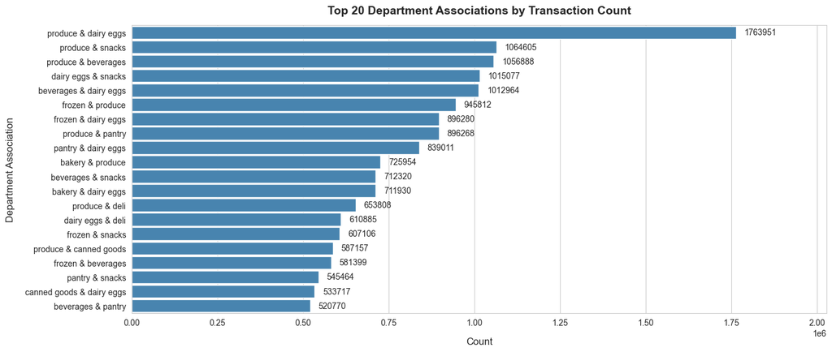

```python
def plot_top_20_department_associations(data):
    data = data.nlargest(20, "Count")[["Count", "DepartmentA", "DepartmentB"]].copy()
    data["Association"] = data["DepartmentA"] + " & " + data["DepartmentB"]
    data = data.drop(columns=["DepartmentA", "DepartmentB"])

    sns.set_style("whitegrid")
    fig, ax = plt.subplots(figsize=(14, 6))

    sns.barplot(
        data=data,
        x="Count",
        y="Association",
        color=sns.color_palette("Blues", n_colors=5)[3],
        width=0.9,
        ax=ax
    )
    for container in ax.containers:
        ax.bar_label(
            container,
            fmt="%.0f",
            padding=10,
            fontsize=10
            #fontweight="bold"
        )
    ax.tick_params(axis='x', rotation=0)
    ax.set_title("Top 20 Department Associations by Transaction Count", fontsize=14, fontweight="bold", pad=14)
    ax.set_xlabel("Count", fontsize=12, labelpad=12)
    ax.set_ylabel("Department Association", fontsize=12, labelpad=12)
    ax.set_xlim(0, data["Count"].max() * 1.15)
    plt.tight_layout()
    plt.show()
plot_top_20_department_associations(depart_pair_df)
```

```python
# def department_association_matrix(data):
#     departments_in_top_20_pairs = data.nlargest(20, "Count")
#     departments_in_top_20_pairs = pd.unique( pd.concat([ departments_in_top_20_pairs["DepartmentA"], departments_in_top_20_pairs["DepartmentB"] ]) )
#     departments = sorted(
#         pd.unique(
#             pd.concat([
#                 data["DepartmentA"],
#                 data["DepartmentB"]
#             ])
#         )
#     )

#     association_matrix = pd.DataFrame(
#         0,
#         index=departments,
#         columns=departments,
#         dtype=int
#     )
#     for row in data.itertuples(index=False):
#         association_matrix.loc[row.DepartmentA, row.DepartmentB] = row.Count
#         association_matrix.loc[row.DepartmentB, row.DepartmentA] = row.Count

#     association_matrix = association_matrix / association_matrix.to_numpy().max()
#     association_matrix = association_matrix.drop( index=association_matrix.index.difference(departments_in_top_20_pairs), columns=association_matrix.columns.difference(departments_in_top_20_pairs) )
#     fig, ax = plt.subplots(figsize=(14, 5))

#     sns.heatmap(
#         association_matrix,
#         cmap="Blues",
#         annot=True,
#         fmt=".2f"
#     )

#     ax.tick_params(axis='x', rotation=0)
#     ax.set_title("Top 20 Department Associations by Number of Transactions", fontsize=14, fontweight="bold", pad=14)
#     ax.set_xlabel("Department", fontsize=12, labelpad=12)
#     ax.set_ylabel("Department", fontsize=12, labelpad=12)
#     plt.tight_layout()
#     plt.show()
# department_association_matrix(depart_pair_df)
```

The following table presents the top 20 department pairs ranked according to Lift. The International department appears prominently among the strongest relationships, together with several non-essential product departments. Lift values are relatively high, indicating that these department pairs occur together substantially more often than would be expected if purchases from the two departments were independent. Some relationships are particularly noteworthy, such as those between Alcohol and Pets or between Personal Care and Pets, although the department-level analysis does not provide sufficient information to explain the underlying reasons for these associations.

```python
depart_pair_df.nlargest(20, "Lift").style.hide(axis="index")
```

| Count | DepartmentA | DepartmentB | CountA | CountB | Support | SupportA | SupportB | Confidence_AtoB | Confidence_BtoA | Lift |
| --- | --- | --- | --- | --- | --- | --- | --- | --- | --- | --- |
| 1876 | other | alcohol | 24006 | 67229 | 0.000645 | 0.008253 | 0.023111 | 0.078147 | 0.027905 | 3.381336 |
| 2905 | alcohol | pets | 67229 | 47449 | 0.000999 | 0.023111 | 0.016312 | 0.043211 | 0.061224 | 2.649076 |
| 17051 | pets | household | 47449 | 436384 | 0.005862 | 0.016312 | 0.150016 | 0.359354 | 0.039073 | 2.395443 |
| 78233 | personal care | household | 237847 | 436384 | 0.026894 | 0.081765 | 0.150016 | 0.328922 | 0.179276 | 2.192580 |
| 7803 | pets | personal care | 47449 | 237847 | 0.002682 | 0.016312 | 0.081765 | 0.164450 | 0.032807 | 2.011263 |
| 82975 | international | canned goods | 206100 | 663495 | 0.028524 | 0.070851 | 0.228090 | 0.402596 | 0.125057 | 1.765077 |
| 223926 | dry goods pasta | canned goods | 581263 | 663495 | 0.076979 | 0.199821 | 0.228090 | 0.385240 | 0.337495 | 1.688986 |
| 584 | other | missing | 24006 | 42675 | 0.000201 | 0.008253 | 0.014670 | 0.024327 | 0.013685 | 1.658255 |
| 451 | other | bulk | 24006 | 33026 | 0.000155 | 0.008253 | 0.011353 | 0.018787 | 0.013656 | 1.654751 |
| 16608 | alcohol | household | 67229 | 436384 | 0.005709 | 0.023111 | 0.150016 | 0.247036 | 0.038058 | 1.646735 |
| 67180 | international | dry goods pasta | 206100 | 581263 | 0.023094 | 0.070851 | 0.199821 | 0.325958 | 0.115576 | 1.631253 |
| 4719 | international | missing | 206100 | 42675 | 0.001622 | 0.070851 | 0.014670 | 0.022897 | 0.110580 | 1.560739 |
| 3815 | babies | missing | 167731 | 42675 | 0.001311 | 0.057661 | 0.014670 | 0.022745 | 0.089397 | 1.550385 |
| 51569 | dry goods pasta | babies | 581263 | 167731 | 0.017728 | 0.199821 | 0.057661 | 0.088719 | 0.307451 | 1.538632 |
| 2987 | other | personal care | 24006 | 237847 | 0.001027 | 0.008253 | 0.081765 | 0.124427 | 0.012558 | 1.521772 |
| 168913 | dry goods pasta | meat seafood | 581263 | 560877 | 0.058067 | 0.199821 | 0.192813 | 0.290597 | 0.301159 | 1.507144 |
| 716 | bulk | missing | 33026 | 42675 | 0.000246 | 0.011353 | 0.014670 | 0.021680 | 0.016778 | 1.477799 |
| 110984 | international | pantry | 206100 | 1073946 | 0.038153 | 0.070851 | 0.369191 | 0.538496 | 0.103342 | 1.458585 |
| 57753 | international | meat seafood | 206100 | 560877 | 0.019854 | 0.070851 | 0.192813 | 0.280218 | 0.102969 | 1.453319 |
| 185245 | meat seafood | canned goods | 560877 | 663495 | 0.063682 | 0.192813 | 0.228090 | 0.330277 | 0.279196 | 1.448015 |

# Product-Level Recommendation Engine

The product association analysis identified pairs of products that tend to be purchased together, providing a basis for generating product recommendations. However, identifying associations alone does not directly provide a mechanism for recommending products to individual customers. A recommendation engine can use these relationships to suggest products that are likely to be purchased together with a product already selected by a customer.

In a retail context, such a system can support cross-selling by presenting relevant complementary products or products with strong purchasing relationships during the shopping process. The recommendation engine developed in this study therefore uses the previously calculated product-level association metrics to identify products that are most strongly associated with a given product.

Given a selected product, for a minimum count threshold of 20, the engine evaluates both directional relationships, Confidence_AtoB and Confidence_BtoA, because the product may appear as either ProductA or ProductB in the pair dataset. The resulting recommendations are ranked according to their confidence, lift and count values.

```python
shopping_cart = [27845, 33754]
def product_level_recommendation(shopping_cart, data, top_n=20):
    data = data[data["Count"] >= 20].copy()
    data = data[~data["ProductA"].isin(shopping_cart[:-1]) & ~data["ProductB"].isin(shopping_cart[:-1])]
    df_AtoB = data[ (data["ProductA"].eq(shopping_cart[-1])) ].nlargest(top_n, "Confidence_AtoB")[["ProductB_Name", "Confidence_AtoB", "Lift", "Count"]].rename(columns={"ProductB_Name" : "RecommendedProduct", "Confidence_AtoB" : "Confidence"})
    df_BtoA = data[ (data["ProductB"].eq(shopping_cart[-1])) ].nlargest(top_n, "Confidence_BtoA")[["ProductA_Name", "Confidence_BtoA", "Lift", "Count"]].rename(columns={"ProductA_Name" : "RecommendedProduct", "Confidence_BtoA" : "Confidence"})
    return pd.concat([df_AtoB, df_BtoA], ignore_index=True).drop_duplicates(subset="RecommendedProduct").nlargest(top_n, ["Confidence", "Lift", "Count"])
product_level_recommendation_df = product_level_recommendation(shopping_cart, pair_df, 20)
product_level_recommendation_df.style.hide(axis="index").set_properties(**{"white-space": "nowrap"})
```

| RecommendedProduct | Confidence | Lift | Count |
| --- | --- | --- | --- |
| Total 2% Lowfat Greek Strained Yogurt With Blueberry | 0.312147 | 45.765621 | 9331 |
| Banana | 0.294818 | 21.604734 | 8813 |
| Total 2% Lowfat Greek Strained Yogurt with Peach | 0.268090 | 40.984379 | 8014 |
| Total 2% All Natural Greek Strained Yogurt with Honey | 0.193089 | 25.512535 | 5772 |
| Total 2% Greek Strained Yogurt with Cherry 5.3 oz | 0.180678 | 30.474602 | 5401 |
| Bag of Organic Bananas | 0.163885 | 5.415930 | 4899 |
| Organic Strawberries | 0.156625 | 3.939353 | 4682 |
| Organic Hass Avocado | 0.097213 | 4.232315 | 2906 |
| Organic Baby Spinach | 0.095006 | 2.943158 | 2840 |
| Organic Avocado | 0.088415 | 8.120467 | 2643 |
| Total 0% Raspberry Yogurt | 0.085672 | 21.454716 | 2561 |
| Organic Fuji Apple | 0.080554 | 2.735206 | 2408 |
| Organic Raspberries | 0.076205 | 1.692190 | 2278 |
| Large Lemon | 0.067942 | 23.029261 | 2031 |
| Half & Half | 0.065467 | 2.878556 | 1957 |
| Strawberries | 0.064697 | 1.377419 | 1934 |
| Organic Whole String Cheese | 0.061319 | 3.127227 | 1833 |
| Limes | 0.059245 | 1.282173 | 1771 |
| Total 0% with Honey Nonfat Greek Strained Yogurt | 0.057338 | 15.533634 | 1714 |
| Sparkling Water Grapefruit | 0.056468 | 2.264683 | 1688 |

# Customer-Level Recommendation Engine

The customer-level product association analysis identified product pairs that were purchased by an individual customer in the past, providing a basis for generating product recommendations. This recommendation engine therefore uses the previously calculated customer-level product association metrics to identify products that are most strongly associated with the last product added to the shopping cart.

Because the number of purchases of individual products in a customer's history may be relatively low, no minimum co-occurrence threshold was applied. The engine evaluates both directional relationships, Confidence_AtoB and Confidence_BtoA, because the selected product may appear as either ProductA or ProductB in the pair dataset. The resulting recommendations are ranked first by Confidence, then by Lift, and finally by Count.

The following table presents the top 20 recommendations for customer 27, using Total 2% with Strawberry Lowfat Greek Strained Yogurt (Product ID 33754) as an example. The recommendations represent the products most strongly associated with this product in the customer's purchase history, assuming that it was added last to the shopping cart and that none of the recommended products had already been selected.

```python
def generate_customer_specific_pairs(user_id):
    baskets = df_all.loc[ df_all["user_id"].eq(user_id) ].groupby("order_id")["product_id"].apply(list)
    baskets = baskets.apply(lambda x: sorted(set(x)))
    baskets = baskets[baskets.str.len() >= 2]

    pair_counter = Counter()

    for basket in baskets:
        pair_counter.update(combinations(basket, 2))

    pair_df = pd.DataFrame(
        pair_counter.items(),
        columns=["Pair", "Count"]
    )
    pair_df[["ProductA", "ProductB"]] = pd.DataFrame(
        pair_df["Pair"].tolist(),
        index=pair_df.index
    )
    pair_df = pair_df.drop(columns="Pair")
    count = baskets.explode().value_counts()
    pair_df["CountA"] = pair_df["ProductA"].map(count)
    pair_df["CountB"] = pair_df["ProductB"].map(count)
    number_of_orders = len(baskets)
    pair_df["Support"] = pair_df["Count"] / number_of_orders
    pair_df["SupportA"] = pair_df["CountA"] / number_of_orders
    pair_df["SupportB"] = pair_df["CountB"] / number_of_orders
    pair_df["Confidence_AtoB"] = pair_df["Count"] / pair_df["CountA"]
    pair_df["Confidence_BtoA"] = pair_df["Count"] / pair_df["CountB"]
    pair_df["Lift"] = pair_df["Count"] * number_of_orders / ( pair_df["CountA"] * pair_df["CountB"] )
    product_id_name = df_all.loc[ df_all["user_id"].eq(user_id) ].groupby("product_id")["product_name"].first()
    pair_df["ProductA_Name"] = pair_df["ProductA"].map(product_id_name)
    pair_df["ProductB_Name"] = pair_df["ProductB"].map(product_id_name)
    department_id_name = df_all.loc[ df_all["user_id"].eq(user_id) ].groupby("product_id")["department"].first()
    pair_df["DepartmentA"] = pair_df["ProductA"].map(department_id_name)
    pair_df["DepartmentB"] = pair_df["ProductB"].map(department_id_name)
    del count, product_id_name, department_id_name
    gc.collect()
    return pair_df
customer_specific_pair_df = generate_customer_specific_pairs(27)
customer_specific_pair_df = reduce_memory_usage(customer_specific_pair_df)
shopping_cart = [27845, 33754]
def customer_level_recommendation(shopping_cart, data, top_n=20):
    data = data[~data["ProductA"].isin(shopping_cart[:-1]) & ~data["ProductB"].isin(shopping_cart[:-1])].copy()
    df_AtoB = data[ (data["ProductA"].eq(shopping_cart[-1])) ].nlargest(top_n, "Confidence_AtoB")[["ProductB_Name", "Confidence_AtoB", "Lift", "Count"]].rename(columns={"ProductB_Name" : "RecommendedProduct", "Confidence_AtoB" : "Confidence"})
    df_BtoA = data[ (data["ProductB"].eq(shopping_cart[-1])) ].nlargest(top_n, "Confidence_BtoA")[["ProductA_Name", "Confidence_BtoA", "Lift", "Count"]].rename(columns={"ProductA_Name" : "RecommendedProduct", "Confidence_BtoA" : "Confidence"})
    return pd.concat([df_AtoB, df_BtoA], ignore_index=True).drop_duplicates(subset="RecommendedProduct").nlargest(top_n, ["Confidence", "Lift", "Count"])
customer_level_recommendation_df = customer_level_recommendation(shopping_cart, customer_specific_pair_df, 20)
customer_level_recommendation_df.style.hide(axis="index").set_properties(**{"white-space": "nowrap"})
```

| RecommendedProduct | Confidence | Lift | Count |
| --- | --- | --- | --- |
| Total 2% Lowfat Greek Strained Yogurt With Blueberry | 0.937500 | 4.191176 | 15 |
| Total 2% Lowfat Greek Strained Yogurt with Peach | 0.937500 | 3.958333 | 15 |
| Total 0% Nonfat Greek Yogurt | 0.750000 | 3.800000 | 12 |
| Total 0% Raspberry Yogurt | 0.625000 | 4.750000 | 10 |
| Natural Artesian Water | 0.625000 | 2.375000 | 10 |
| Total 2% Greek Strained Yogurt with Cherry 5.3 oz | 0.562500 | 4.750000 | 9 |
| Total 2% All Natural Greek Strained Yogurt with Honey | 0.562500 | 4.750000 | 9 |
| Pure Coconut Water | 0.437500 | 1.108333 | 7 |
| Sparkling Grapefruit | 0.375000 | 3.562500 | 6 |
| Sparkling Clementine Juice | 0.375000 | 2.850000 | 6 |
| Natural Artisan Water | 0.375000 | 1.295455 | 6 |
| Yogurt, Organic, Lowfat, Strawberry | 0.312500 | 3.958333 | 5 |
| Total with Strawberry Yogurt | 0.312500 | 3.392857 | 5 |
| Grape White/Green Seedless | 0.312500 | 2.968750 | 5 |
| Teriyaki Turkey Jerky | 0.312500 | 2.968750 | 5 |
| Blackberry Yogurt | 0.250000 | 4.750000 | 4 |
| Organic Blueberries | 0.250000 | 3.166667 | 4 |
| Sparkling Blackberry Juice | 0.250000 | 3.166667 | 4 |
| Original Turkey Jerky | 0.250000 | 3.166667 | 4 |
| Bag of Organic Bananas | 0.250000 | 2.714286 | 4 |

# Combined Recommendation Engine

The final recommendation engine combines the product-level and customer-level recommendation results to incorporate both general purchasing patterns and customer-specific purchasing behaviour. Recommendations generated at product level reflect associations observed across the entire dataset, while customer-level recommendations are based exclusively on the historical purchasing behaviour of the individual customer. By combining both sources of information, the engine can identify recommendations supported by either general or personalized purchasing patterns, while products appearing in both sources provide evidence of an association at both levels. When the same product is identified by both engines, the recommendation supported by the strongest Confidence, followed by Lift and Count, is retained.

If the customer-level engine does not identify any products associated with the last product added to the shopping cart, only the product-level recommendations are presented.

```python
def combined_recommendation(data1, data2, top_n=20):
    data1, data2 = data1.copy(), data2.copy()
    products_both = set(data1["RecommendedProduct"]) & set(data2["RecommendedProduct"])
    data1["Source"] = "Product-level"
    data2["Source"] = "Customer-level"
    data = pd.concat([data1, data2], ignore_index=True)
    data["Source"] = np.where(data["RecommendedProduct"].isin(products_both), "Product + Customer", data["Source"])
    data = data.sort_values(["Confidence", "Lift", "Count"], ascending=[False]*3).drop_duplicates(subset="RecommendedProduct")
    return data.head(top_n)
combined_recommendation(product_level_recommendation_df, customer_level_recommendation_df, 20).style.hide(axis="index").set_properties(**{"white-space": "nowrap"})
```

| RecommendedProduct | Confidence | Lift | Count | Source |
| --- | --- | --- | --- | --- |
| Total 2% Lowfat Greek Strained Yogurt With Blueberry | 0.937500 | 4.191176 | 15 | Product + Customer |
| Total 2% Lowfat Greek Strained Yogurt with Peach | 0.937500 | 3.958333 | 15 | Product + Customer |
| Total 0% Nonfat Greek Yogurt | 0.750000 | 3.800000 | 12 | Customer-level |
| Total 0% Raspberry Yogurt | 0.625000 | 4.750000 | 10 | Product + Customer |
| Natural Artesian Water | 0.625000 | 2.375000 | 10 | Customer-level |
| Total 2% Greek Strained Yogurt with Cherry 5.3 oz | 0.562500 | 4.750000 | 9 | Product + Customer |
| Total 2% All Natural Greek Strained Yogurt with Honey | 0.562500 | 4.750000 | 9 | Product + Customer |
| Pure Coconut Water | 0.437500 | 1.108333 | 7 | Customer-level |
| Sparkling Grapefruit | 0.375000 | 3.562500 | 6 | Customer-level |
| Sparkling Clementine Juice | 0.375000 | 2.850000 | 6 | Customer-level |
| Natural Artisan Water | 0.375000 | 1.295455 | 6 | Customer-level |
| Yogurt, Organic, Lowfat, Strawberry | 0.312500 | 3.958333 | 5 | Customer-level |
| Total with Strawberry Yogurt | 0.312500 | 3.392857 | 5 | Customer-level |
| Grape White/Green Seedless | 0.312500 | 2.968750 | 5 | Customer-level |
| Teriyaki Turkey Jerky | 0.312500 | 2.968750 | 5 | Customer-level |
| Banana | 0.294818 | 21.604734 | 8813 | Product-level |
| Blackberry Yogurt | 0.250000 | 4.750000 | 4 | Customer-level |
| Organic Blueberries | 0.250000 | 3.166667 | 4 | Customer-level |
| Sparkling Blackberry Juice | 0.250000 | 3.166667 | 4 | Customer-level |
| Original Turkey Jerky | 0.250000 | 3.166667 | 4 | Customer-level |

In a real-world implementation, additional business-related variables could also be incorporated into the recommendation ranking. For example, inventory availability should be considered to avoid recommending products that are currently out of stock. Product price could be introduced as a third ranking criterion after Confidence and Lift to explore recommendations with greater potential for revenue generation, while preserving the strength of the purchasing relationship as the primary criterion. Product prices are not available in the dataset used in this study, and therefore were not included in the ranking.

# Cold-Start Consideration for New Products

A limitation of association-based recommendation systems is the cold-start problem associated with newly introduced products. A product with no historical purchase records cannot be directly associated with other products through the methods applied in this study. However, product-level information such as the product name and department could provide an alternative source of information for identifying similar existing products.

A possible approach would first restrict the candidate products to the same department and then compare product names using a text-based similarity method, such as TF-IDF with cosine similarity. The most similar existing products could subsequently be used as proxies for the new product, allowing their established purchase associations to provide an initial set of recommendations.

To illustrate a possible approach to the cold-start problem, the product "Total 2% with Strawberry Lowfat Greek Strained Yogurt" (product_id=33754) was temporarily treated as a newly launched product, and its historical records were excluded from the candidate dataset.

```python
data = df_all[~df_all["product_id"].eq(33754)] # "Total 2% with Strawberry Lowfat Greek Strained Yogurt"
new_product = "Total 2% with Strawberry Lowfat Greek Strained Yogurt"
department_id = df_all[df_all["product_id"].eq(33754)].drop_duplicates("product_id")["department_id"].iloc[0] # 16 #"dairy eggs"
candidates = data.loc[ data["department_id"].eq(department_id), ["product_id", "product_name"] ].drop_duplicates()
vectorizer = TfidfVectorizer()
tfidf = vectorizer.fit_transform( candidates["product_name"].tolist() + [new_product] )
similarity = cosine_similarity(tfidf[-1], tfidf[:-1]).ravel()
candidates = candidates.copy()
candidates["Similarity"] = similarity
candidates.nlargest(10, "Similarity").style.hide(axis="index").set_properties(**{"white-space": "nowrap"})
```

| product_id | product_name | Similarity |
| --- | --- | --- |
| 4957 | Total 2% Lowfat Greek Strained Yogurt With Blueberry | 0.868597 |
| 33787 | Total 2% Lowfat Greek Strained Yogurt with Peach | 0.850141 |
| 29599 | Total Greek Strained Yogurt with Blueberry | 0.797271 |
| 39475 | Total Greek Strained Yogurt | 0.785623 |
| 16097 | Total with Cherry Greek Strained Yogurt | 0.774112 |
| 43369 | Total with Mango Greek Strained Yogurt | 0.761194 |
| 32739 | Total 2% Cherry Lowfat Greek Strained Yogurt | 0.758222 |
| 11925 | Total 2% with Raspberry Pomegranate Lowfat Greek Strained Yogurt | 0.752612 |
| 33370 | Total with Strawberry Yogurt | 0.743528 |
| 4414 | Total 0% with Raspberry Nonfat Greek Strained Yogurt | 0.716764 |

The results show that the method identifies highly similar products, with the highest-ranked candidates sharing several descriptive characteristics with the new product, including the brand, product type, fat content, and Greek strained yogurt classification. Flavour similarities are also captured, with several products containing different fruit varieties appearing among the highest-ranked candidates. This demonstrates how product-name similarity could provide an initial source of information for new products for which no purchase history is yet available. These similar products could subsequently be used as proxies for the last product added to the shopping cart when generating initial association-based recommendations.

# Key-Findings

- Product associations are strongly influenced by product popularity. The most frequently purchased pairs are dominated by food products, particularly fresh produce, but co-occurrence count alone does not necessarily indicate a strong association.
- Confidence and Lift identify different and stronger relationships. Several highly confident or high-Lift product pairs occur substantially less frequently than the most common pairs, demonstrating the importance of considering association metrics beyond purchase frequency.
- Strong product relationships are predominantly within departments. Among the top 100 relationships, 83% of the highest-confidence pairs and 78% of the highest-Lift pairs involve products from the same department, although substantial cross-department relationships also exist.
- Customer-level associations provide additional personalization. Individual customers can exhibit highly concentrated purchasing patterns, and their historical product associations can differ substantially from the relationships observed across the entire customer population.
- Department-level aggregation weakens the observed associations. Although several department pairs occur very frequently, their Lift values are considerably lower than those observed at product level, indicating that strong product-level relationships are not necessarily preserved when products are aggregated into departments.
- Combining global and customer-specific associations provides a more flexible recommendation approach. The combined recommendation engine incorporates both population-wide and individual purchasing behaviour, while product-name similarity provides a potential solution for new products with no purchase history.

# Conclusions

This study demonstrated how market basket analysis can be used to identify product associations and develop recommendation engines from transactional retail data. Product-level associations revealed strong purchasing relationships that are not necessarily apparent from purchase frequency alone, while customer-level associations provided an additional layer of personalization based on individual purchasing history.

The combination of global and customer-specific associations resulted in a flexible recommendation approach, with product-name similarity identified as a potential extension for addressing new products with no purchase history. In a real-world implementation, additional business-related variables, such as product price, could also be incorporated into the ranking criteria to explore recommendations with greater potential to increase revenue while preserving Confidence and Lift as the primary measures of association strength. Overall, the analysis demonstrates how transactional purchase data can be transformed into practical, association-based recommendations while providing several opportunities for further development in a real-world retail environment.